# Python Visualizations - Quick Start Guide

**by Giancarlo Marchesi**

This notebook explores commercial airplane flight delays in the United States from 2011 to 2020 using python visualizations through the lenses of seasonality, airport traffic, and airline performance.

The dataset contains flight statistics for all airports in the United States. Each observation is reported by month, year, airport and airline. Flights can be categorized as ontime, delayed, cancelled or diverted. Flight delays are attributed to five causes: carrier, weather, NAS, security and late aircraft.

The data was downloaded from the Bureau of Transportation Statistics website https://www.transtats.bts.gov/OT_Delay/OT_DelayCause1.asp. The clean dataset contains 157,906 observations.

This notebook complements EDA_quickstart_airports.ipynb, which can also be found in this repository. https://github.com/gmarchesiv/Quickstart_EDA_Visualizations

The analysis solve the following questions using the proposed visualizations.

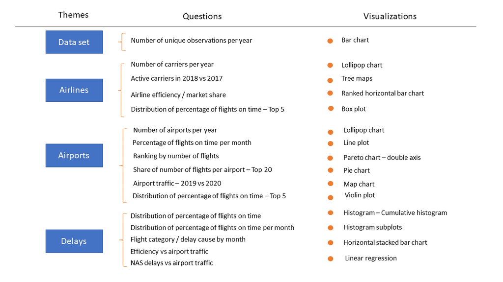

### Bar chart

Bar charts are a quick way to visualize the basics of a dataset. Let's begin by asking how many observations are in the dataset for each year.

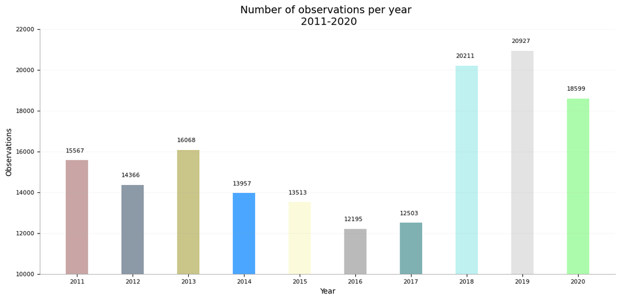

There is a very marked difference in the average number of observations per year between 2016-2017 and 2018-2020. Why?

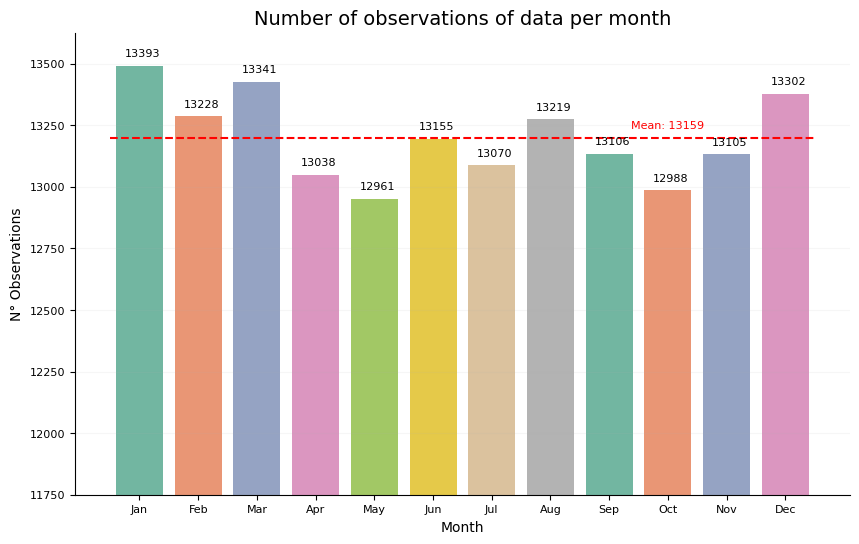

January shows the most observations and May the least. January perhaps activates a few more routes for New Year's holidays. May has Memorial day weekend, which marks the beginning of summer, yet it's below the mean. July is also below the mean, it's the middle of summer and includes 4th of July holiday. These two results are a little counterintuitive. Does this pattern hold for all years?

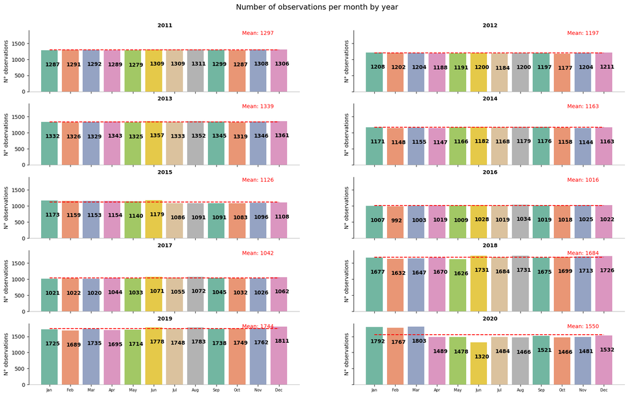

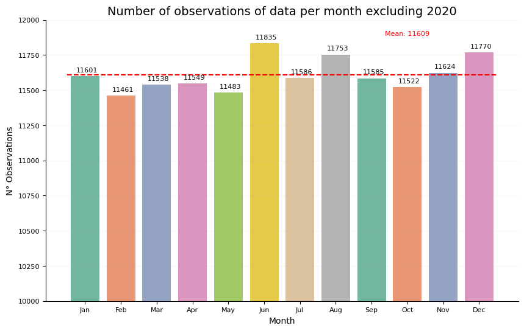

In typical years, June, August and December are the most travelled months. Previously, January had been more relevant because the first three months of 2020 were similar to other years. June, August and December of 2020 were lower than an average year. February and May are the months with less observations. July is about average.

### Lollipop chart

Lollipop charts are similar to bar charts. They can provide additional space if there are too many bars in the figure. It's not necessarily the case here, but let's introduce them for further reference. How have the number of carriers and airports evolved over the years?

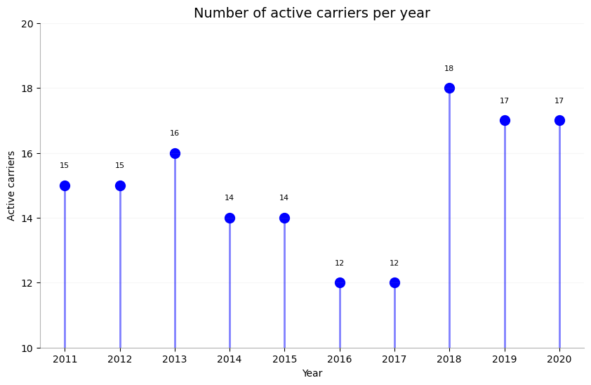

There are indeed fewer carriers in the years 2016 and 2017 than in the following years.

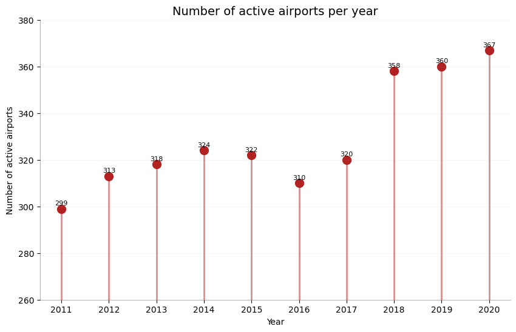

There is also an increase in number of airports int 2018-2020. So both effects are increasing the amount of observations in the data set after 2017.

### Tree maps

Tree maps are a convenient way to present the elements of a set, with an additional quantitative dimension like the percentage or absolute value of a variable. In this case, its visual nature helps us figure out which are the new carriers in 2018 at a simple glance.

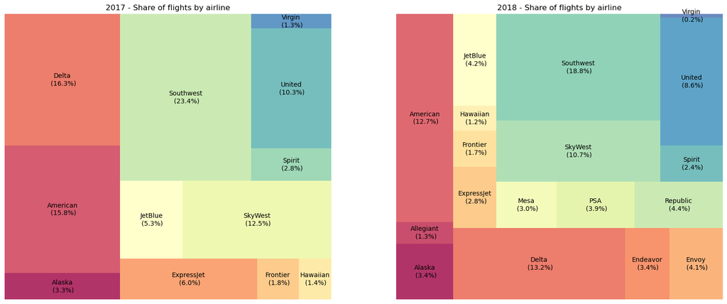

The new carriers introduced in 2018 are Allegiant, Endeavor, Envoy, Mesa, PSA & Republic

### Line plot

Line plots are the easiest way to see the trend of a variable over time. Let's start with the percentage of flights on time per month ovr the years to look for trends. Is there seasonality? Has efficiency increased over time?

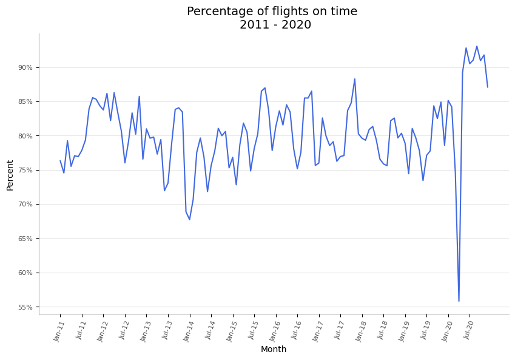

The percentage of flights on time seems to oscilate around a mean of ~80%, so this point could be some seasonality. Also, 2020 is a clear outlier because of COVID. An upward trend would be tricky to confirm. The number of years are not enough, considering that 2020 is not really representative.

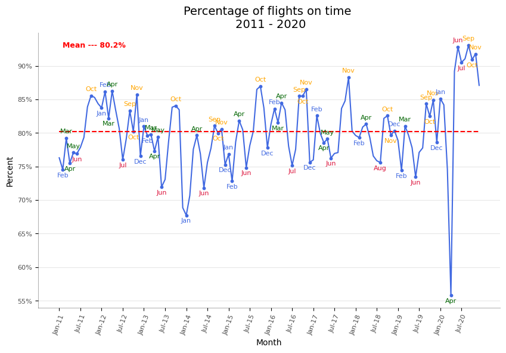

Now we see the prevalence of spring (green) and fall months (yellow) as the most efficient ones (i.e. March, April, September, October). On the contrary, summer and winter months are less efficient. This is expected because of holidays and weather.

### Histograms

Histrograms show the distributions of variables. In this case, we want to know the distribution of flights on time for all aiports in the dataset, which includes data for all months and years they operated.

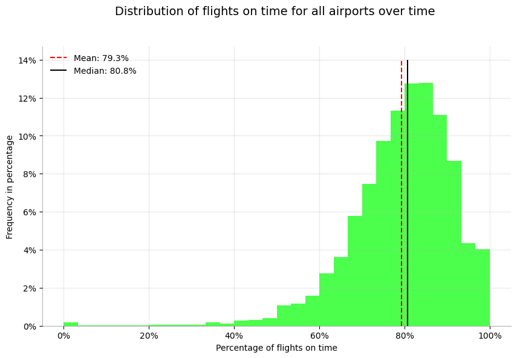

The distribution is not normal. Although, the mean and median are close to 80%, there is a long tail on the left, i.e. some aiports had very bad delay problems. Perhaps, this could be attributed to having very few flights or operated for short periods.

#### Cumulative distribution of percentage of flights on time

The next figure is another view of the same query. We see that the median monthly share of ontime flights hovers around 80%. Less than 20% of the distribution of observations have bad efficiency (~70% or less of flights are on time).

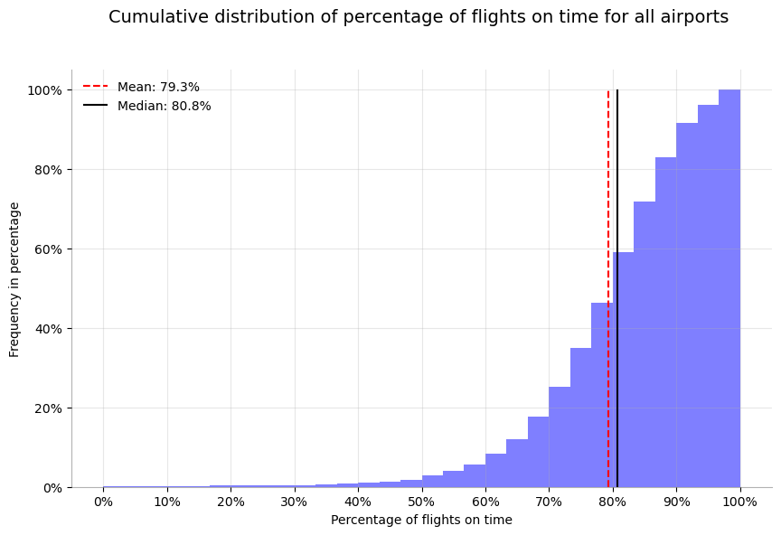

### Histogram subplots

We can use a subplot (4 rows, 3 columns) to check the distributions at the monthly level and calculate the means and medians.

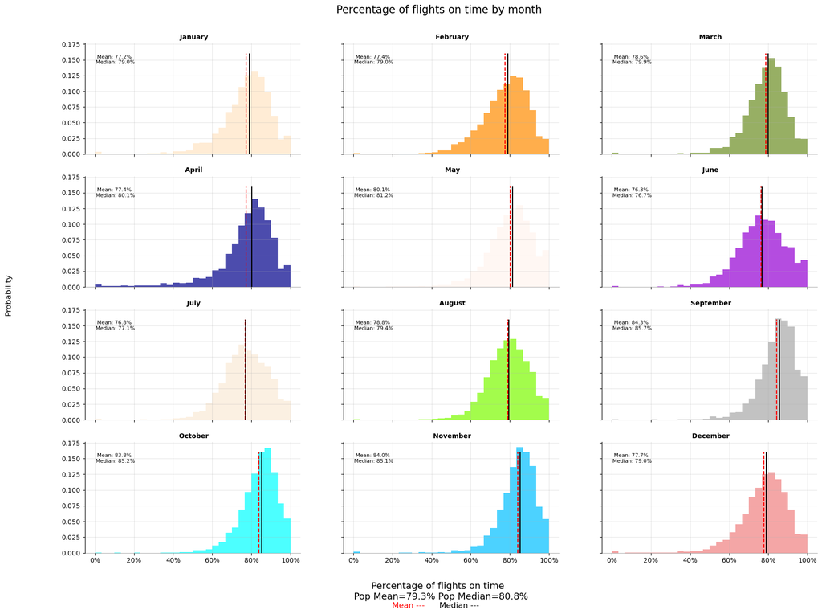

At a glance, the months of summer and winter have more delays than the months of spring and fall.

### Horizontal stacked bar chart

This bar chart shows the composition of a variable, in either relative or absolute terms, over time. In this example, the stacks add to 100% to understand how flight arrival categories and types of delays change from month to month in the sample.

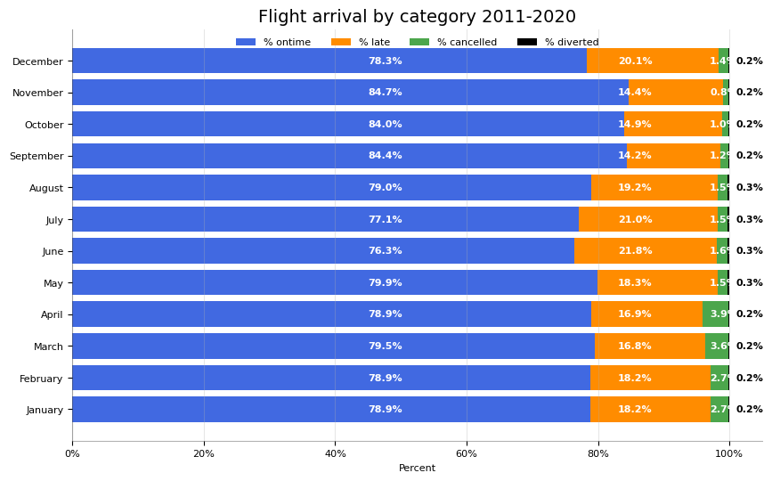

On average, the most efficient months are September, October and November, while June and July show the largest share of late flights.

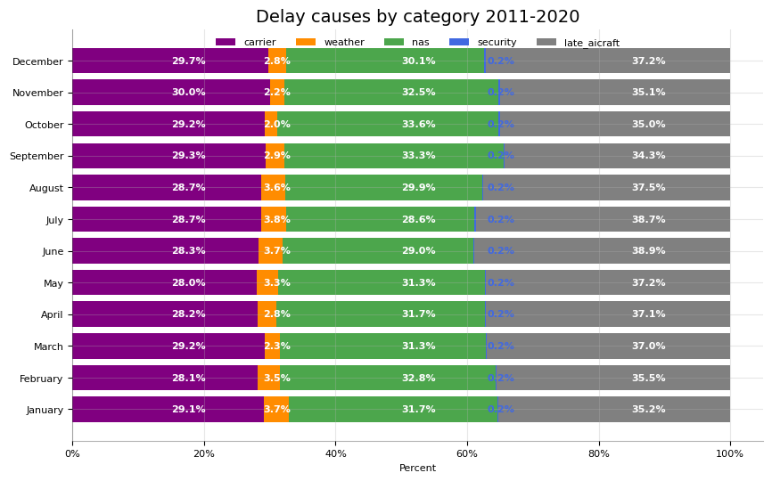

Late aircraft and carrier delays show similar numbers. They acount for roughly 65% of total delays. Aircraft are particularly late in the months of summer. NAS is at its highest during hurricane season (fall).

Delays or cancellations coded "NAS" are the type of weather delays that could be reduced with corrective action by the airports or the Federal Aviation Administration. Hence, they are separate from an expected "weather" event. During 2020, slightly less than half of NAS delays were due to weather according to the Bureau of Transport Statistics (BTS). Airport operations, heavy traffic volume, and air traffic control are other causes for NAS delays.

### Ranked horizontal bar chart

These charts provide a quick sense of the ranking of a variable. Which is the most efficient airline, i.e. the one with the highest share of flights on time? Which airline has the largest market share? How are these two variables related? Let's find out.

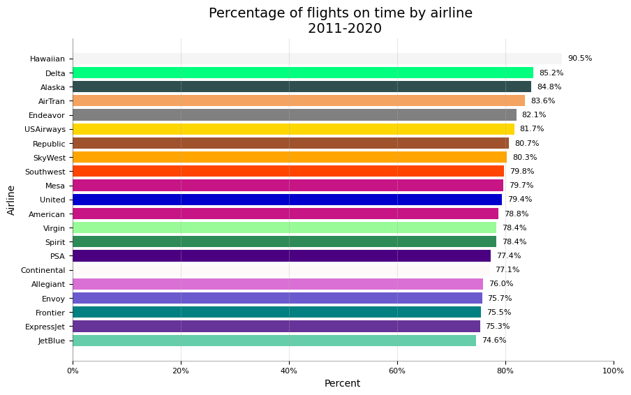

Hawaiian is the most efficient airline. Delta is in second place, despite being a major airline.

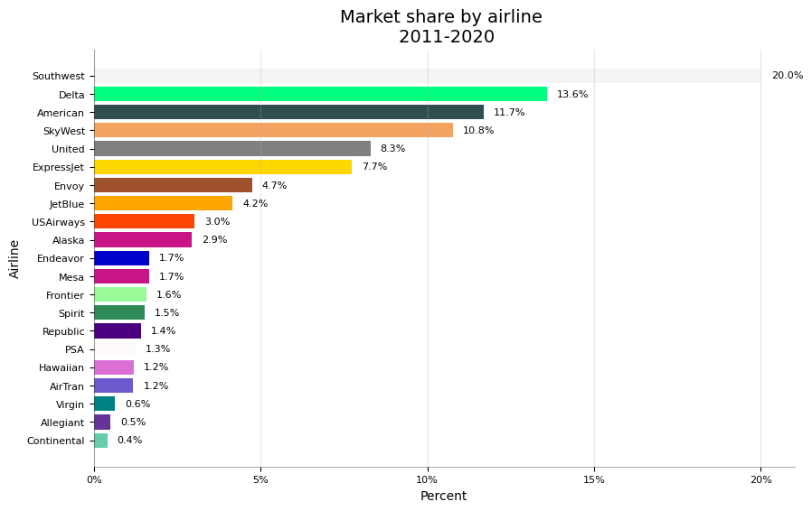

Delta has the best overall performance. It's the second most efficient despite having the second largest market share.

### Box Plot

Box plots are a great way to visualize the distribution, keeping the median, 25th, 75th quartiles and the outliers in mind. In this case, we'll look at the distribution of percent of flights on time for the top 5 airlines by market share: Southwest, Delta, American, SkyWest and United.

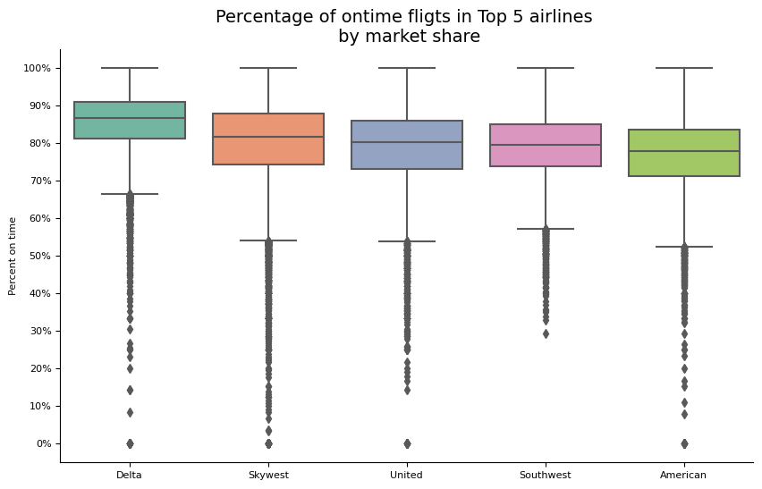

Delta is the most consistent in terms of the percentage of timely flights, with a median close to 85%. American performs slighlty below this group, at around 77%.

### Pareto chart - double axis

Pareto charts show how the elements of the set contribute to the cumulative distribution. Let's see how many airports contribute to 50% of the distribution, 80% and 95%.

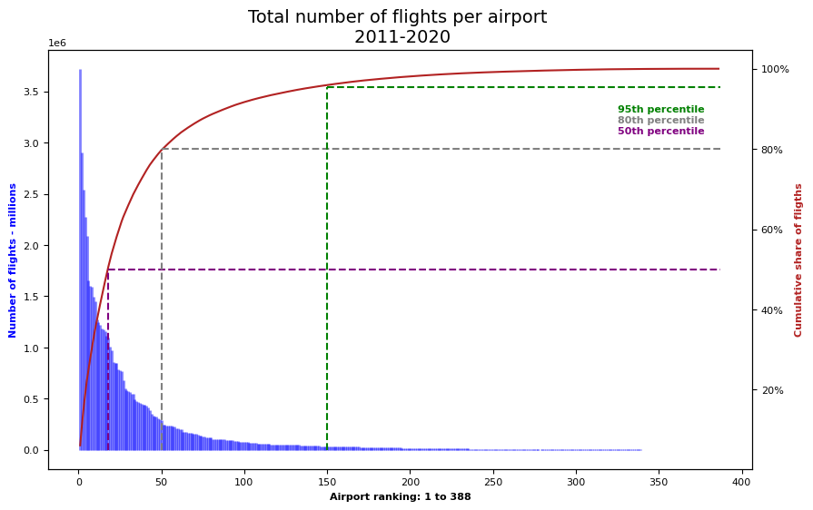

18 airports make 50% of flight traffic in the USA, 50 airports make 80%, 150 aiports make 95%.

### Pie charts

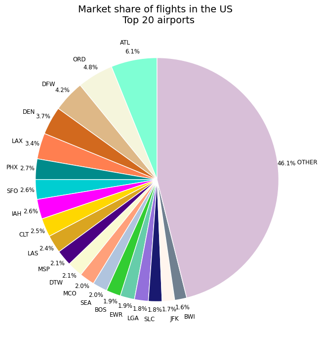

The top 20 aiports make 54% of the total market share. Atlanta (ATL) is the busiest airport, with Chicago (ORD), Dallas (DFW), Denver (DEN) and Los Angeles (LAX) rounding the top 5.

### Scatter plot

Scatteplots are used to study the relationship between two variables. In the case of multiple groups in the data, each group can be visualized in a different color. Let's analyze the relationship between percentage of flights on time an airport trafic among the top 20 aiports. The plot is divided into four zones, separated by the means of both variables: overperforming, underperforming, efficient and average.

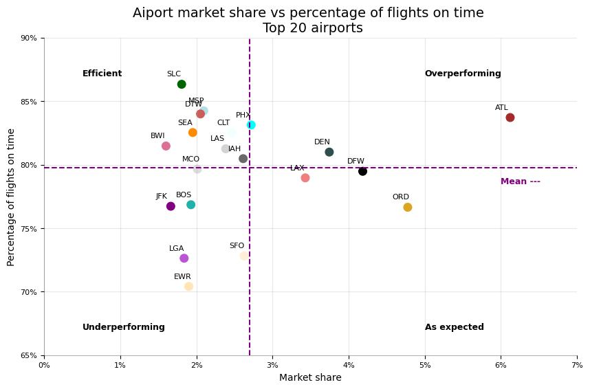

Salt lake city (SLC) is the most efficient airport. Among the top 5 airports by market share, the best performing airport is Atlanta (ATL). Newark (ERW) is the worst performer among the top 20.

### Violin plot

Violin plots are another way to visualize the distribution of a variable. The shape or area of the violin depends on the number of observations it holds. The median, 25th, 75th quartiles and the outliers can be marked inside the figure. In this case, we'll look at the distribution of percent of flights on time for the top 5 airports by market share: ATL, DEN, LAX, DFW and ORD.

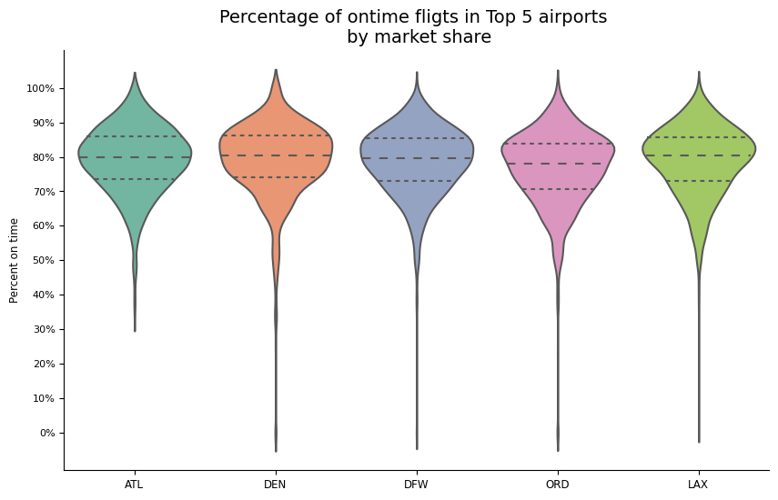

Although the medians of the 5 airports are pretty close, Atlanta's distribution has a shorter tail and is thicker in the third quartile, which is why it's average is higher than the other four.

### Map Chart

Let's use the longitude and latitude of the top 10 aiports to see the changes between a non-COVID year (2019) and 2020. I will use the geopandas library to graph them on a map of the US.

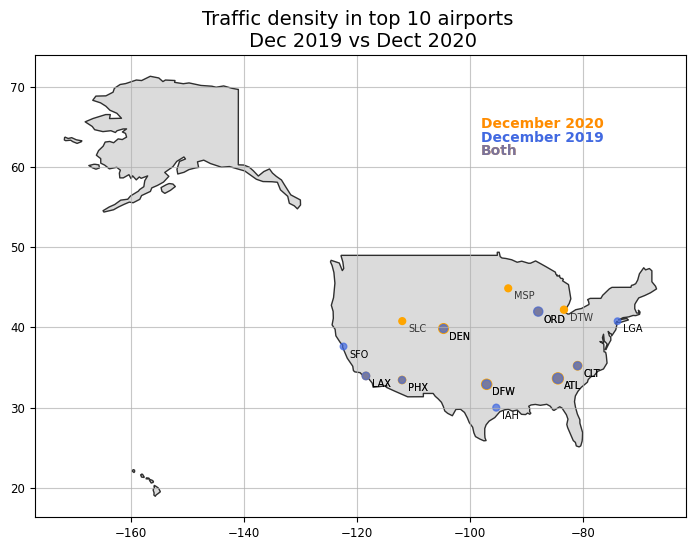

LGA, SFO and IAH were replaced in 2020 by Salt Lake City (SLC), Minneapolis (MSP) and Detroit (DTW). During COVID, international travel was restricted in NY, SF and Houston.

### Linear regression

Regression is a parametric technique used to predict a dependent variable given one or a set of independent variables. Let's find out if there are statistically significant relationships between airport traffic and efficiency and the latter with NAS delays.

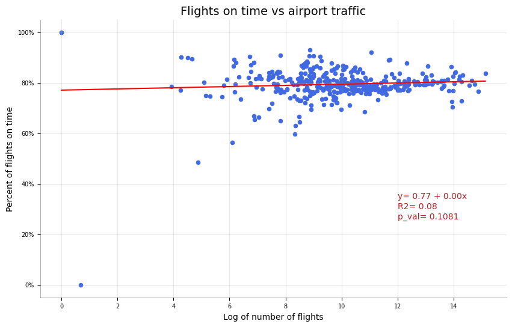

Graphically, size appears to have some effect on airport efficiency. But the the R2 is small, and the p_value is not statistically significant.

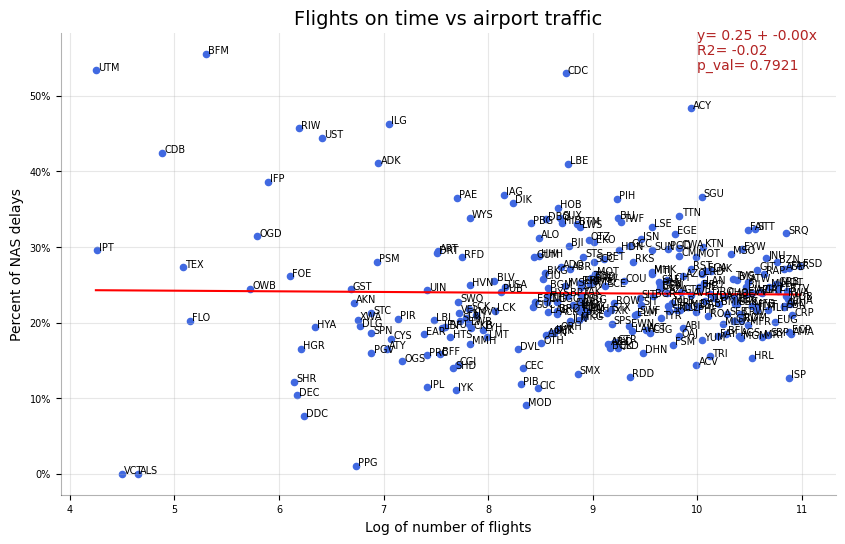

There doesn't seem to be a relationship between percent of nas delays and size of the aiport for medium-sized airports. The p-value is above the statistically significant threshold. The R2 is very low.

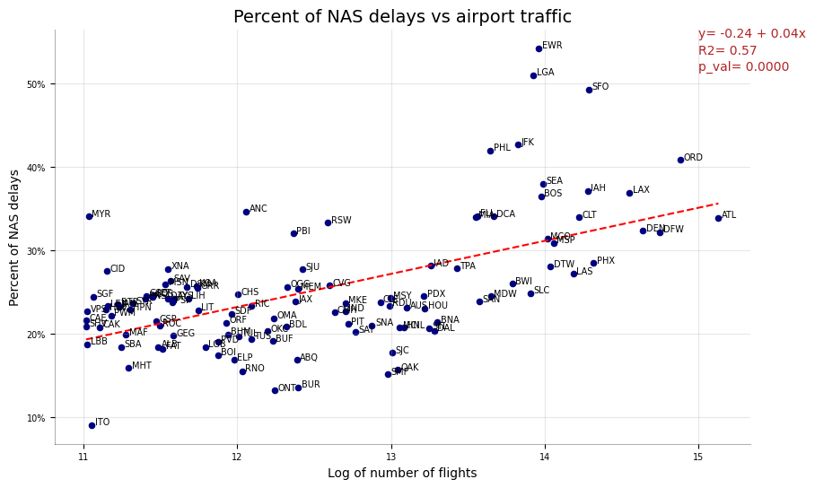

For large airports, the relationship is statistically significant at the 95% level. We see quite a few of the larger airports above the regression line. There is some evidence to support the hypothesis that larger airports tend to have higher percentage of NAS delays, which could be reduced with corrective action by the airports or the Federal Aviation Administration.

**Conclusions from the analysis of the four cross sectional dimensions**

**Yearly Trend**

- There is no noticeable yearly trend in the percentage of flights ontime during the decade of data. The size of the sample is small (10 yearly data points) and 2020 is skewed because of the pandemic.

**Seasonality**

- Seasonality is present, with a lower amount of flights ontime, on average, during the months of summer (June, July) and winter (December, January). This probably has to do with weather (heavy rains or snow) and traffic (holiday season).

**Carriers**

**Airports**